# STA305/1004 - Homework #3

Due Date: March 17, 2017

If you work with other students on this assignment then:

- indicate the names of the students on your solutions;
- your solutions must be written up independently (i.e., your solutions should not be the same as another students solutions).
1. Suppose that twenty independent two-sample t tests are conducted at the 0.05 level, and that all the null hypotheses are true.
1. What is the distribution of the total number of tests that will be significant? How many tests do you expect would produce a significant result? Briefly explain.

Let $X$ be the total number of significant tests. Since $H_0$ is true in every test the probability that a test rejects is 0.05, and all the tests are independent this implies that $X\sim Bin(20,0.05)$. $E(X)=20(0.05)=1$.

2. The following R code simulates two independent t-tests based on sample sizes of 100 when $H_0$ is true and calculates the probaility at least one $H_0$ is rejected.

```r
y1 <-replicate(1000,t.test(rnorm(100,0,1),rnorm(100,0,1))$p.value)
y2 <-replicate(1000,t.test(rnorm(100,0,1),rnorm(100,0,1))$p.value)
sum(y1<=0.05|y2<=0.05)/1000
```

NB: The R code `sum(y1<=0.05 | y2 <=0.05)` means add up all the elements of `y1` or `y2` that are less than or equal to 0.05. So for example the code below checks if each element of `y1` or `y2` is less than or equal to 0.05. If at least one of the elements is less than or equal to 0.05 then it is counted in the sum.

```r
y1 <- c(0.01,0.06,0.03)
y2 <- c(0.05,0.09,0.07)
y1<=0.05|y2<=0.05
```

```
## [1]  TRUE FALSE  TRUE
```

```r
sum(y1<=0.05|y2<=0.05)
```

```
## [1] 2
```

Use simulation to calculate the probability that at least one null hypothesis is rejected among the twenty studies. Does this probability correpond to a type I or type II error? Briefly explain.

```r
set.seed(303)
y1 <-replicate(1000,t.test(rnorm(100,0,1),rnorm(100,0,1))$p.value)
y2 <-replicate(1000,t.test(rnorm(100,0,1),rnorm(100,0,1))$p.value)
y3 <-replicate(1000,t.test(rnorm(100,0,1),rnorm(100,0,1))$p.value)
y4 <-replicate(1000,t.test(rnorm(100,0,1),rnorm(100,0,1))$p.value)
y5 <-replicate(1000,t.test(rnorm(100,0,1),rnorm(100,0,1))$p.value)
y6 <-replicate(1000,t.test(rnorm(100,0,1),rnorm(100,0,1))$p.value)
y7 <-replicate(1000,t.test(rnorm(100,0,1),rnorm(100,0,1))$p.value)
y8 <-replicate(1000,t.test(rnorm(100,0,1),rnorm(100,0,1))$p.value)
y9 <-replicate(1000,t.test(rnorm(100,0,1),rnorm(100,0,1))$p.value)
y10 <-replicate(1000,t.test(rnorm(100,0,1),rnorm(100,0,1))$p.value)
y11 <-replicate(1000,t.test(rnorm(100,0,1),rnorm(100,0,1))$p.value)
y12 <-replicate(1000,t.test(rnorm(100,0,1),rnorm(100,0,1))$p.value)
y13 <-replicate(1000,t.test(rnorm(100,0,1),rnorm(100,0,1))$p.value)
y14 <-replicate(1000,t.test(rnorm(100,0,1),rnorm(100,0,1))$p.value)
y15 <-replicate(1000,t.test(rnorm(100,0,1),rnorm(100,0,1))$p.value)
y16 <-replicate(1000,t.test(rnorm(100,0,1),rnorm(100,0,1))$p.value)
y17 <-replicate(1000,t.test(rnorm(100,0,1),rnorm(100,0,1))$p.value)
y18 <-replicate(1000,t.test(rnorm(100,0,1),rnorm(100,0,1))$p.value)
y19 <-replicate(1000,t.test(rnorm(100,0,1),rnorm(100,0,1))$p.value)
y20 <-replicate(1000,t.test(rnorm(100,0,1),rnorm(100,0,1))$p.value)

sum(y1<=0.05|y2<=0.05|y3<=0.05|y4<=0.05|y5<=0.05|y6<=0.05|y7<=0.05|y8<=0.05|y9<=0.05|y10<=0.05|y11<=0.05|y12<=0.05|y13<=0.05|y14<=0.05|y15<=0.05|y16<=0.05|y17<=0.05|y18<=0.05|y19<=0.05|y20<=0.05)/1000
```

```
## [1] 0.625
```

This probability is a type I error rate since it is the probability of rejecting when $H_0$ is true.

3. Suppose that $k$ independent t-tests are conducted at level $\alpha$. Show that

$$P\left(\text{at least one }H_0 \text{ rejected} \right)=1-\left(1-\alpha \right)^k.$$
This is called the experimentwise error rate. Verify by choosing $\alpha$ and $k$ that the results from the simulation in part (c) agree with this probability.

$$\begin{aligned}
P\left(\text{at least one }H_0 \text{ rejected} \right) &= 1-P\left(\text{none of }H_0 \text{ rejected}\right) \\
&= 1-\left[P\left(H_{0_1} \text{not rejected} \right)P\left(H_{0_2} \text{not rejected}\right) \cdots P\left(H_{0_{k}} \text{not rejected}\right) \right] \\
&= 1-\left[(1-\alpha)(1-\alpha) \cdots (1-\alpha)\right] \\
&= 1-(1-\alpha)^k
\end{aligned}$$

In part (c) we have $k=20$ and $\alpha=0.05$ so

```r
1-(1-.05)^(20)
```

```
## [1] 0.6415141
```

The simulation yields 0.625. The accuracy of the simulation would increase if the number of simulations were increased.

4. Does that probability in part (c) increase or decrease as $k$ increases for a fixed $\alpha$? Interprete this probability in terms of conducting multiple hypothesis tests.

The probability increases as $k$ increases. The experimentwise error rate is the probability that at least one of the tests will incorrectly reject $H_0$. There is a 0.64 probability that this will be the case.

5. Consider a study of the effects of a person’s sex (e.g., male or female) on salary at a university. In such a case, it would be impossible to assign subjects to be men or women, but a nonrandomized study might be conducted by carefully matching males to females on factors such as age and years of experience. In one study fifty variables were recorded for each subject such as promotion, external awards, articles cited, and number of children born. After termination of the study, the male and female salaries were compared on each of these fifty variables, and it was found that there was a “significant difference (at the 1% level)” in the salary between men and women that had a large number of highly cited articles during their career. Explain why there might be a problem with this “significant finding”.

The probability that at least one one null hypothesis will be incorrectly rejected is at most

```r
1-(1-0.01)^50
```

```
## [1] 0.3949939
```

There is a 0.39 probability of mistakingly declaring that at least one of these fifty results is significant when it is not. So, there is a reasonable probability that the difference in salary between men and women with large numbers of highly cited articles is due to chance.

2. (Adapted from Wu, Hamada, 2009) The following experiment was performed at a pulp mill. Plant performance is based on pulp brightness as measured by a reflective meter. Each of the shift operators (dentoted A, B, C, and D) made five pulp handsheets from unbleached pulp. Reflectance was read for each of the handsheets using a brightness tester as reported in the table below:

   | A | B | C | D |
   | --- | --- | --- | --- |
   | 59.8 | 59.8 | 60.7 | 61.0 |
   | 60.0 | 60.2 | 60.7 | 60.8 |
   | 60.8 | 60.4 | 60.5 | 60.6 |
   | 60.8 | 59.9 | 60.9 | 60.5 |
   | 59.8 | 60.0 | 60.3 | 60.5 |

The goal of the experiment is to determine whether there are differences between the operators in making the handsheets and reading thier brightness.

1. What is the null and alternative hypothesis corresponding to the experimental goal. Calculate the means and standard deviations for each operator. Based on these summary statistics is there evidence of difference between operators?

$H_0: \mu_1=\mu_2=\mu_3=\mu_4$ versus $H_1:\mu_i \ne \mu_j$. The opeartor means and standard deviations are:

```r
sapply(split(reflect,operator),mean)
```

```
##     A     B     C     D
## 60.24 60.06 60.62 60.68
```

```r
sapply(split(reflect,operator),sd)
```

```
##         A         B         C         D
## 0.5176872 0.2408319 0.2280351 0.2167948
```

2. Use R to fit the following model to the data using the default coding `contr.treatment(4)`.

$$y_{ij}=\eta+\tau_i+\epsilon_{ij},$$
where $i=1,..,4, j=1,...,5$, where $y_{ij}$ is the $j^{th}$ observation with operator $i$.

```r
contrasts(pulpdat$operator) <- contr.treatment(4)
mod1 <- lm(reflect~operator,data=pulpdat)
summary(mod1)
```

```
##
## Call:
## lm(formula = reflect ~ operator, data = pulpdat)
##
## Residuals:
##    Min     1Q Median     3Q    Max
## -0.440 -0.195 -0.070  0.175  0.560
##
## Coefficients:
##             Estimate Std. Error t value Pr(>|t|)
## (Intercept)  60.2400     0.1458 413.243   <2e-16 ***
## operator2    -0.1800     0.2062  -0.873   0.3955
## operator3     0.3800     0.2062   1.843   0.0839 .
## operator4     0.4400     0.2062   2.134   0.0486 *
## ---
## Signif. codes:  0 '***' 0.001 '**' 0.01 '*' 0.05 '.' 0.1 ' ' 1
##
## Residual standard error: 0.326 on 16 degrees of freedom
## Multiple R-squared:  0.4408, Adjusted R-squared:  0.3359
## F-statistic: 4.204 on 3 and 16 DF,  p-value: 0.02261
```

- Interpret the model parameters $\eta, \tau_i, \epsilon_{ij}$ and their associated p-values.

$\eta$ is mean of operator A, $\tau_i$ is the mean of the $i^{th}$ operator minus the mean of operator A.

- What do you assume about $\epsilon_{ij}$? Check if these assumptions are fulfilled.

Assume that $\epsilon_{ij} \sim N(0,\sigma^2)$. To check the constant variance assumption and normality of residuals we can inspect the following two plots:

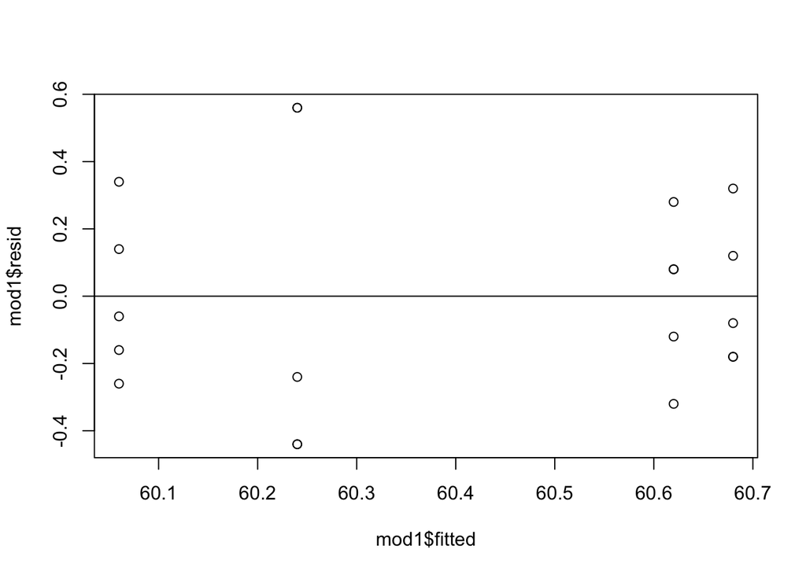

```r
plot(mod1$fitted,mod1$resid);abline(h=0)
```

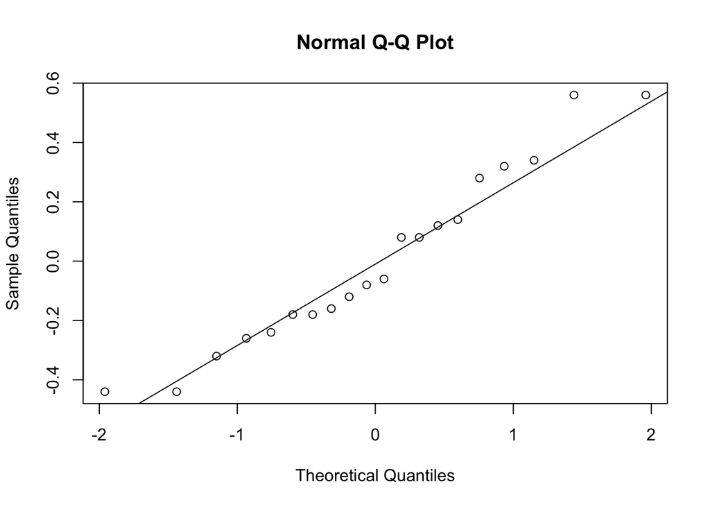

```r
qqnorm(mod1$resid);qqline(mod1$resid)
```

Hand in your R output.

3. Recode your model in part (b) using deviation coding (see example code). The contrast matrix for this coding scheme is:

```r
contr.sum(4)
```

```
##   [,1] [,2] [,3]
## 1    1    0    0
## 2    0    1    0
## 3    0    0    1
## 4   -1   -1   -1
```

Using deviation coding define dummy variables $x_{1j},x_{2j},x_{3j}$ so that the model is
$$y_{ij}=\eta+\tau_1 x_{1j}+\tau_2 x_{2j}+\tau_3 x_{3j} + \epsilon_{ij}$$
.

$$x_{i1} = \left\{
\begin{array}{ll}
1 & \mbox{if operator A} \\
-1 & \mbox{if operator D}
\end{array} \right.$$

$$x_{i2} = \left\{
\begin{array}{ll}
1 & \mbox{if operator B} \\
-1 & \mbox{if operator D}
\end{array} \right.$$

$$x_{i3} = \left\{
\begin{array}{ll}
1 & \mbox{if operator C} \\
-1 & \mbox{if operator D}
\end{array} \right.$$

Interpret the parameter estimates from this model. Which coding scheme gives more interpretable parameter estimates? Why? Hand in your R output.

```r
contrasts(pulpdat$operator) <- contr.sum(4)
mod2 <- lm(reflect~operator,data=pulpdat)
summary(mod2)
```

```
##
## Call:
## lm(formula = reflect ~ operator, data = pulpdat)
##
## Residuals:
##    Min     1Q Median     3Q    Max
## -0.440 -0.195 -0.070  0.175  0.560
##
## Coefficients:
##             Estimate Std. Error t value Pr(>|t|)
## (Intercept) 60.40000    0.07289 828.681   <2e-16 ***
## operator1   -0.16000    0.12624  -1.267    0.223
## operator2   -0.34000    0.12624  -2.693    0.016 *
## operator3    0.22000    0.12624   1.743    0.101
## ---
## Signif. codes:  0 '***' 0.001 '**' 0.01 '*' 0.05 '.' 0.1 ' ' 1
##
## Residual standard error: 0.326 on 16 degrees of freedom
## Multiple R-squared:  0.4408, Adjusted R-squared:  0.3359
## F-statistic: 4.204 on 3 and 16 DF,  p-value: 0.02261
```

The intercept is the mean of the sample means.

```r
attach(pulpdat)
sum(sapply(split(reflect,operator),mean))/4
```

```
## [1] 60.4
```

The estimate of operator1 is then 60.24-60.40=-0.16. The other estimates are defined in a similar fashion.

4. Use R to calculate the ANOVA table for the pulp experiment. What do you conclude? Hand in your R output.

```r
anova(mod1)
```

```
## Analysis of Variance Table
##
## Response: reflect
##           Df Sum Sq Mean Sq F value  Pr(>F)
## operator   3   1.34 0.44667  4.2039 0.02261 *
## Residuals 16   1.70 0.10625
## ---
## Signif. codes:  0 '***' 0.001 '**' 0.01 '*' 0.05 '.' 0.1 ' ' 1
```

5. For the pulp experiment show that neither the Bonferroni nor the Tukey method declares any pair of treatments as different at the 0.01 level. Hand in your R output.

```r
attach(pulpdat)
pairwise.t.test(reflect,operator,conf.level=0.99,p.adj = "bonf")
```

```
##
##  Pairwise comparisons using t tests with pooled SD
##
## data:  reflect and operator
##
##   A     B     C
## B 1.000 -     -
## C 0.503 0.092 -
## D 0.292 0.050 1.000
##
## P value adjustment method: bonferroni
```

```r
TukeyHSD(aov(reflect~operator),conf.level=0.99)
```

```
##   Tukey multiple comparisons of means
##     99% family-wise confidence level
##
## Fit: aov(formula = reflect ~ operator)
##
## $operator
##      diff        lwr       upr     p adj
## B-A -0.18 -0.9368427 0.5768427 0.8185430
## C-A  0.38 -0.3768427 1.1368427 0.2903038
## D-A  0.44 -0.3168427 1.1968427 0.1844794
## C-B  0.56 -0.1968427 1.3168427 0.0657945
## D-B  0.62 -0.1368427 1.3768427 0.0376691
## D-C  0.06 -0.6968427 0.8168427 0.9910783
```

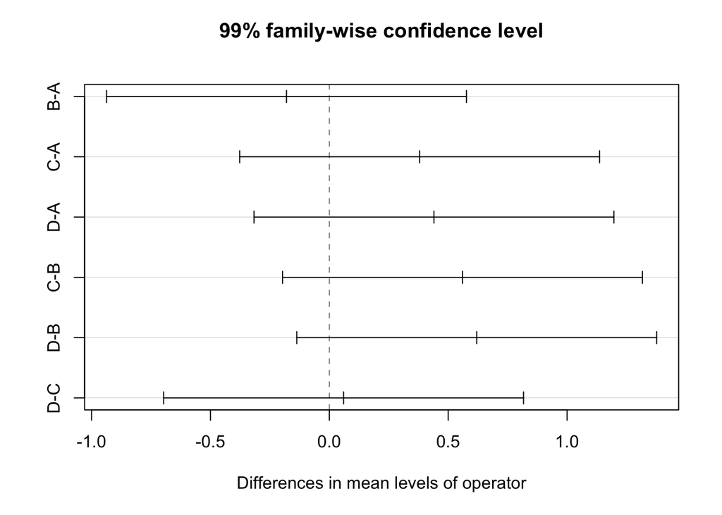

```r
plot(TukeyHSD(aov(reflect~operator),conf.level=0.99))
```

6. How do you reconcile the finding in (e) with the result that the F test rejects the null hypothesis at the 0.05 level? After rejecting the null hypothesis do you expect the multiple comparison method to identify at least one pair of treatments as different?

The F test was rejected at the 0.05 level, but adjusted p-values using Bonferroni and Tukey are compared to the 0.01 level.

7. Recall that the p value for the observed F statistic value is 0.02. How can you use this fact to reach the same conclusion in (e) without actually performing comparisons?

At least one of the operator differences is significant at the 0.02 level. If we adjust for multiple comparisons then the significance threshold will be even smaller.

3. (Adapted from Box, Hunter and Hunter) A study was conducted to determine the effects of individual bathers on the fecal and total coliform bacterial populations in water. The variables of interest were the time since the subject’s last bath, the vigor of the subject’s activity in the water, and the subject’s sex. The experiments were perfomed in a 100-gallon polyethylene tub using dechlorinated tap water at 38°C. The bacterial contribution of each bather was determined by subtracting the bacterial concentration measured at 15 and 30 minutes from that measured initially. A replicated $2^3$ factorial design was used for this experiment. The data obtained are presented below. (Note: Because the measurement of bacterial populations in water involves a dilution technique, the experimental errors do not have constant variance. Rather, the variation increases with the value of the mean.) Perform analysis using a logarithmic transfomation of the data (the natural logarithm in R is obtained from the function `log()`).

| run | x1 | x2 | x3 | y1 | y2 | y3 | y4 |
| --- | --- | --- | --- | --- | --- | --- | --- |
| 1 | -1 | -1 | -1 | 1 | 1 | 3 | 7 |
| 2 | 1 | -1 | -1 | 12 | 15 | 57 | 80 |
| 3 | -1 | 1 | -1 | 16 | 10 | 323 | 360 |
| 4 | 1 | 1 | -1 | 4 | 6 | 183 | 193 |
| 5 | -1 | -1 | 1 | 153 | 170 | 426 | 590 |
| 6 | 1 | -1 | 1 | 129 | 148 | 250 | 243 |
| 7 | -1 | 1 | 1 | 143 | 170 | 580 | 450 |
| 8 | 1 | 1 | 1 | 113 | 217 | 650 | 735 |
| 9 | -1 | -1 | -1 | 2 | 4 | 10 | 27 |
| 10 | 1 | -1 | -1 | 37 | 39 | 280 | 250 |
| 11 | -1 | 1 | -1 | 21 | 21 | 33 | 53 |
| 12 | 1 | 1 | -1 | 2 | 5 | 10 | 87 |
| 13 | -1 | -1 | 1 | 96 | 67 | 147 | 193 |
| 14 | 1 | -1 | 1 | 390 | 360 | 1470 | 1560 |
| 15 | -1 | 1 | 1 | 300 | 377 | 665 | 810 |
| 16 | 1 | 1 | 1 | 280 | 250 | 675 | 795 |

1. Briefly explain why this is a $2^3$ factorial design.

There are 3 factors each at 2 levels. The experiment was run at all factor-level combinations.

2. Calculate the factorial effects (main and interaction effects) on fecal and total coliform populations after 15 and 30 minutes. Hand in your R output.

```r
fact1 <- lm(log(y1)~x1*x2*x3,data=prb0506)
summary(fact1)
```

```
##
## Call:
## lm(formula = log(y1) ~ x1 * x2 * x3, data = prb0506)
##
## Residuals:
##     Min      1Q  Median      3Q     Max
## -0.5630 -0.3525  0.0000  0.3525  0.5630
##
## Coefficients:
##             Estimate Std. Error t value Pr(>|t|)
## (Intercept)  3.50844    0.14137  24.817 7.43e-09 ***
## x1           0.16198    0.14137   1.146   0.2850
## x2           0.10723    0.14137   0.758   0.4699
## x3           1.67275    0.14137  11.832 2.39e-06 ***
## x1:x2       -0.66725    0.14137  -4.720   0.0015 **
## x1:x3       -0.04614    0.14137  -0.326   0.7525
## x2:x3       -0.03122    0.14137  -0.221   0.8308
## x1:x2:x3     0.47530    0.14137   3.362   0.0099 **
## ---
## Signif. codes:  0 '***' 0.001 '**' 0.01 '*' 0.05 '.' 0.1 ' ' 1
##
## Residual standard error: 0.5655 on 8 degrees of freedom
## Multiple R-squared:  0.9564, Adjusted R-squared:  0.9183
## F-statistic: 25.09 on 7 and 8 DF,  p-value: 7.735e-05
```

```r
#Factorial Effects - multiply regression parameter estimates by two
2*fact1$coefficients
```

```
## (Intercept)          x1          x2          x3       x1:x2       x1:x3
##  7.01688428  0.32396639  0.21445503  3.34550317 -1.33449621 -0.09228555
##       x2:x3    x1:x2:x3
## -0.06244021  0.95059054
```

3. Let $w_1, w_2$ be the results from two individual runs under the same conditions from this $2^3$ factorial design. For example, the responses for Fecal coliform contribution after 15 minutes (y1) under the condition $x_1, x_2, x_3$ set at -1 -1 -1 are 1 and 2 respectively. (runs 1 and 9).

Show that the estimated variance $s_i^2, i=1,...,16$ at the $i^{th}$ conditions is:
$$s_i^2=\frac{\left ( w_1-w_2 \right)^2}{2}.$$

The variance of $w_1, w_2$ is $s_i^2=\sum_{i=1}^2 \frac{\left(w_i - {\bar w} \right)^2}{2-1}.$

$$\begin{equation}
\begin{split}
s_i^2 & = \left(w_1 - \frac{\left(w_1+w_2 \right)}{2} \right)^2 + \left(w_2 - \frac{\left(w_1+w_2 \right)}{2} \right)^2 \\
& = \left(\frac{w_1}{2} - \frac{w_2}{2} \right)^2 + \left(\frac{w_2}{2} - \frac{w_1}{2} \right)^2 \\
& = \left(\frac{w_1-w_2}{2}\right)^2 + \left((-1)\frac{(w_1-w_2)}{2} \right)^2 \\
& = 2 \left(\frac{w_1-w_2}{2}\right)^2 \\
& = \frac{\left ( w_1-w_2 \right)^2}{2}.
\end{split}
\end{equation}$$

4. Use the result in part (c) to show that the variance of any of the factorial effects in a $2^3$ factorial design with replicated runs is
   $$V(effect)=\left(\frac{1}{8}+\frac{1}{8}\right)s^2,$$
   where $s^2=\frac{\sum_{i=1}^8 s_i^2}{8}.$

Let $effect={\bar y_{+}}-{\bar y_{-}}$, where for the first effect of a $2^3$ design ${\bar y_{+}}=\frac{y_2+y_4+y_6+y_8}{4}$ and ${\bar y_{-}}=\frac{y_1+y_3+y_5+y_7}{4}$. Since the design is replicated each observation is the average of the two duplicate runs, $y_i=\frac{y_{i1}+y_{i2}}{2}$, and $V(y_i)=\frac{\sigma^2}{2}.$ Therefore,

$$\begin{aligned}
V(effect) &= V \left(\frac{y_{2}+y_4+y_6+y_8}{4} + \frac{ y_1+y_3+ y_5+y_7}{4} \right) \\
&= \frac{1}{16} \left(4 \frac{\sigma^2}{2} \right) + \frac{1}{16} \left(4 \frac{\sigma^2}{2} \right) \\
& = \frac{1}{8} \sigma^2 + \frac{1}{8} \sigma^2
\end{aligned}$$

$\sigma^2$ can be estimated by $s^2$. Therefore $V(effect)= \left(\frac{1}{8}+ \frac{1}{8} \right)s^2$.